# Linear models lecture

## Introduction

## History

- ANOVA, ANCOVA, regression, \(t\) test are all variations of the same animal, the *general* linear model
- Many people (including the R project) call it a linear model (`lm`) to distinguish it from the *generalized* linear model (`glm`)
- these models are typical fit by ordinary least squares

## (part of) the statistical universe

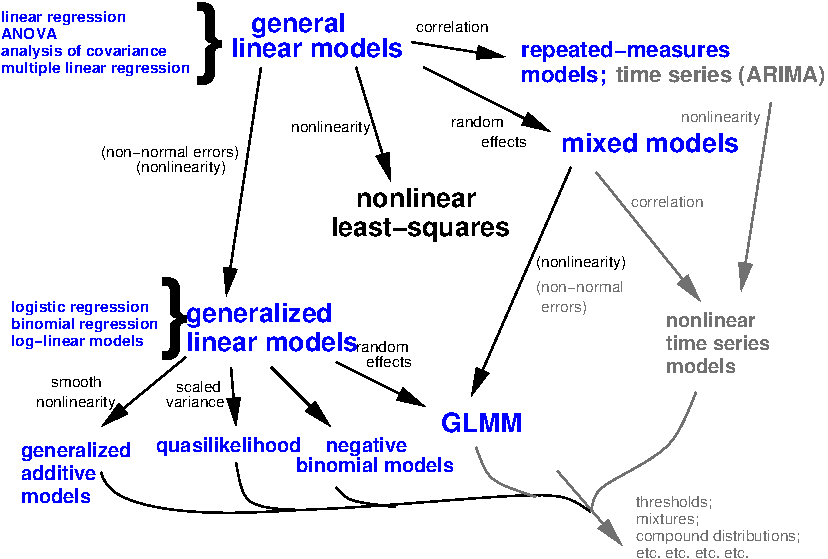

## Extended linear models

- *Generalized* linear models can incorporate:
  - (Some) non-linear relationships
  - Non-normal response *families* (binomial, Poisson, …)
- *Mixed* models incorporate *random effects*
  - Categories in data represent samples from a population
  - e.g. species, sites, genes …
  - Traditionally used to account for experimental blocks

## Basic theory

## Assumptions

- *Response variables* are linear functions of *input variables*, in turn based on *predictor variables*
  - Can have one or more input variables per predictor variable
  - Each input variable is associated with an estimated parameter (more about this later)
- *Errors* or *residuals* are Normally distributed
  - In other words, the difference between our model *predictions* and our observations is Normal
  - *not* assuming the marginal distribution is Normal (e.g. a histogram of an input variable)
  - (Go to board/paper for residual drawing)
- Predictor variables are independent

## Machinery

- *least squares* fit - we get parameters that minimize the squared differences between predictions and observations
- Least squares fits have a lot of nice properties
- Sensitive to some departures from the assumptions
  - anomalous events tend to have a larger effect than they should

## One-parameter variables - continuous

- Continuous predictor variable: estimate a straight line with one parameter
  - Also implies one *input variable*
- \(Y = a+bX\)
- \(Y\) is the response
- \(X\) is the input variable
- \(b\) is the *slope* and the expected change in Y per unit change in X

## One-parameter variables - categorical

- Categorical predictor variable with two categories: only one parameter
  - difference in predicted value between levels
- Parameters are (usually) easy to interpret
  - Go to R example

## Multi-parameter variables

- With more than two categories, there is more than one input variable (parameter) associated with a single predictor variable
- A note: Non-linear response to a predictor variable
  - Might be able to use a linear model!
  - \(Y = a + bX + cX^2\) is linear in \(a\) and \(b\) (the unknowns)

## Diagnostics

- Because the linear model is sensitive (sometimes!) to assumptions, it is good to evaluate them
- Concerns:
  - *Heteroscedasticity* (does variance change across the data set, check diagnostic plots)
  - Linearity (does your model fit well?)
  - Normality (assuming no overall problems, do your **residuals** look Normal?)
    - What test would I use for this?
  - Independence (no autocorrelation)
    - current value is independent of the previous (historic) values - important for time series data
- Normality is the **least important** of these assumptions

## Default plots in R

```r
par(mfrow=c(2,2))  # set 2 rows and 2 column plot layout
mod_1 <- lm(mpg ~ disp, data=mtcars)  # linear model
plot(mod_1)
```

[output not shown]

## Default plots in R - Heteroscedasticity

- The plots on the left look at variance across the range of fitted values
- They ask - as variable one increases, is it’s explanatory ability similar across all values? These plots should be flat. Points should be randomly scattered.

## Default plots in R - Normality of Residuals

- The plot on the top right examines normality of residuals - this line should be 1:1. It may be easier to examine with a shapiro-wilk test

## Default plots in R - leverage of points

- The plot on the bottom right examines which points have the greatest influence on the regression. I do not recommend removing “real” outlier points but you should examine you results with and without them to see how much they influence your inference.

## Diagnostic plots in code…

## Some other assumptions

- the number of datapoints is greater than the number of predictors
- there is some variability in the values of your predictor (e.g. x is not the same)
- your predictors aren’t perfectly correlated (e.g. multicollinearity)
  - you can check this with corrplot

## Correlation plots - which are correlated?

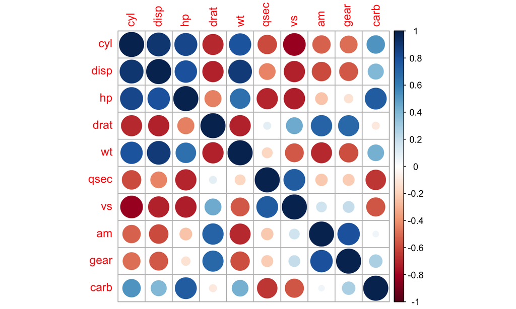

##Deciding what is “too”” correlated - variance inflation factors give an estimate of the multicollinearity among variables - they assess how much the variance of an estimated regression coefficient increases if your predictors are correlated - > 4: investigate; >8-10 is cause for serious concern (sometimes ppl say even lower) - if no factors are correlated, the VIFs will all be 1 - any multicollinearity (even less than 8) can change regression coefs (try it!) - removing variables is necessary, and will depend on data

## Resources

http://r-statistics.co/Assumptions-of-Linear-Regression.html - Go to R

## Transformations

- One way to deal with problems in model assumptions is by transforming one or more of your variables
- Transformations are not cheating: a transformed scale may be as natural (or more natural) a way to think about your data as your original scale
- The linear scale (no transformation) often has direct meaning, if you are adding things up or scaling them (as in our ant example)
- The log scale is often the best scale for thinking about physical quantities: 1:10 as 10:?

## Transformation tradeoffs

- A transformation may help you meet model assumptions
  - Homoscedasticity
  - Linearity
  - Normality
- But there is no guarantee that you can fix them all
- Piles of zeros are hard too (consider GLMs)

## Transformations to consider

- log-lin, lin-log and log-log for various sorts of exponential and power relationships
- Box-Cox and Yeo-Johnson (takes negative values)
  - Note: *Box-Cox transformation* tries out transformations of the form \((y^\lambda-1)/\lambda\) (\(\lambda=0\) corresponds to log-transformation)
- Avoid classical ‘transform then linear model’ recommendations for
  - probability data or count data
  - Generally better to respect the structure of these data with a GLM

## Deciding whether to transform

- It’s **not OK** to pick transformations based on trying different ones and looking at P values
- It’s probably OK to decide based on a measure of Normality of residuals

## Tools for fitting and inference

## Basic tools

- `lm` fits a linear model
- `summary` prints statistics associated with the *parameters* that were fitted
- [see code]

## Multiple comparisons

- One standard of practice is to take a variable-level P value and then evaluate patterns in the response to significant variables
- Straightforward, but maybe not conservative
- `TukeyHSD` does multiple comparison tests on objects produced by `aov`. Can also use `glht` in the `multcomp` package more generally.
- Note: `aov` is just another way of calling `lm`, whereas `anova` *compares* different model fits.
- [see code]

## Plotting

- `plot` can be applied to an `lm` object to give you a nice set of diagnostic tests.
- `predict` can give predicted values, and standard errors.
- In `ggplot`, `geom_smooth(method="lm")` fits a linear model to each group of data (i.e. each group that you have identified by plotting it in a different colour, within a different facet, etc.
  - [see code]

## Assignment - Thursday

- Use ex7_linear_models.R as a guide
- Make a univariate linear model for one of your hypotheses
- Examine the assumptions of linearity (using tests and diagnostic plots)
- Explain what these are telling you (it’s okay if they aren’t normal, but tell me why)
- Plot the relationship in ggplot using stat_smooth or stat_summary
- You can hold off on submitting this assignment (which will be done via github) until after next weeks assignment
- Remember to update your README file - we will combine this week and next week so you can indicate that in your file

## `Performance` package - Thursday

- The performance package is a useful package for doing model checks and improves on some of the plots in base R
- You can read more about it here:
- https://easystats.github.io/performance/
- https://easystats.github.io/see/articles/performance.html

## Basic model diagnostic plots with `performance`

- first you will need to install the package and run it

```r
#install.packages(performance)

#load performance
library(performance)
```

## Make the ants dataframe again and run simple model

```r
forest <- c(9, 6, 4, 6, 7, 10)
field  <- c(12, 9, 12, 10)
ants <- data.frame(
  place=rep(c("field","forest"),
            c(length(field), length(forest))),
  colonies=c(field,forest),
  observers=c(1,3,2,1,5,2,1,2,1,1)
)

l1 <- lm(colonies~observers, data = ants)
```

## Diagnostic plots using check_model in the performance package

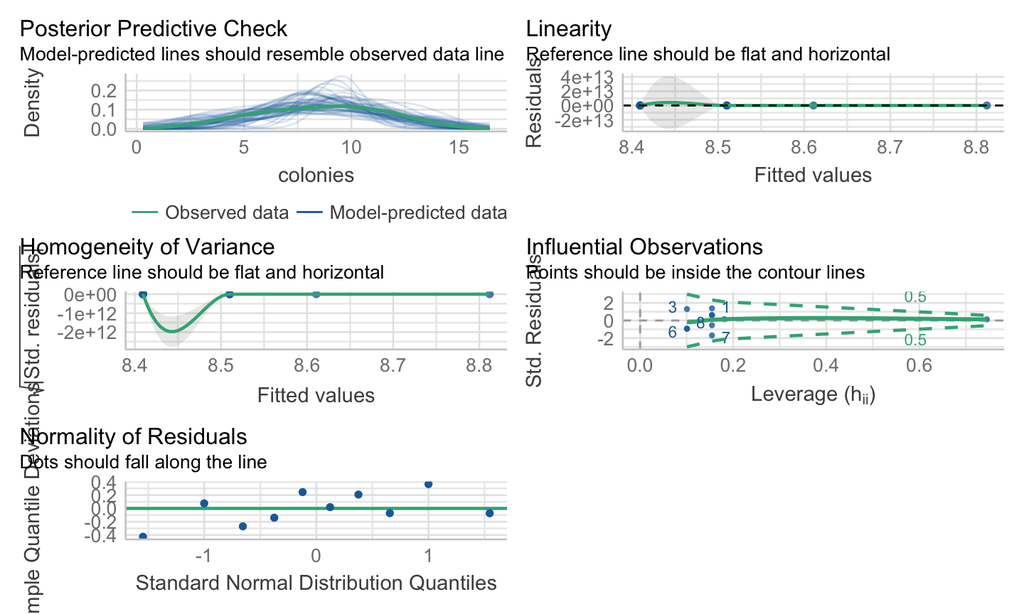

```r
check_model(l1)
```

## What do these tell you?

- The output is similar to base R but the annotation is better!
- Posterior predictive checks (Bayesian) can be used to “look for systematic discrepancies between real and simulated data by seeing whether similating the regression coefs result in lines that look like our data
- top right - linearity: okay, probably can proceed
- homogeneity of variance: definitely some areas where the variance isn’t homogeneous across all values of x
- influence ok
- normality of residuals okay

## Extensions

- The performance package is very powerful and has many uses beyond this simple checks
- We’ll talk more about these when we do glms, but it’s worth familiarizing yourself with them now
- For the assignment, you can use either base R or the performance package but you might at least consider selecting the performance package to prepare yourself for future weeks